# Time Series Coursework 1

### 2.2 Dyplot

```r
#Here, I have created a 'dyplot'. I encountered a warning sign when I ran the function of changing my select function. However, I do not have select functions on my code. Therefore, to make my knitting neater, I decided to use the 'suppress warning' function to create a tidier look on my workbook.
suppressWarnings(prophet::dyplot.prophet(seasonalityfit,prediction,xlab = "Years", ylab = "CO2 Concentration (ppm)",main= "Prediction & Actual rates of CO2 over the years"))
```

[interactive chart not shown]

In this study, a crucial tool used is an interactive graph that vividly illustrates the correlation between the predicted and actual rates of CO2 over the years. By dragging the interactive X-axis, you can examine the graph more closely, analyse the concentration levels at specific months, and compare the predictions to the actual figure.

As we can see, CO2 levels are increasing yearly, and the two variables have a clear positive correlation. By analysing the graph closer, we can see that the concentration of carbon dioxide fluctuates yearly. However, in May, it is at its peak with the highest concentration and gradually decreases to its lowest concentration in September and October. CO2 being at its optimum during May could result from photosynthesis; during this period, plants only begin photosynthesis, meaning they start to absorb the CO2, leading to a decrease after May. However, outside factors could prevent all CO2 from being absorbed, leading to a gradual increase over the years.

In this graph, the blue line shows the prediction of CO2 levels, and the black dots are the actual values. As we can see, there are few outliers within this dataset, and the shape of each year is very similar. As we can see, the predictions were very close to the actual values. In May 1962, the CO2 value was predicted to be 321.12 ppm, but the actual value was slightly lower at 320.85 ppm. This indicates that the values were overpredicted. In May of 1970, the forecasted level amounted to 328.38ppm, whereas the predicted level was 327.91ppm, resulting in a difference of 0.47ppm. The CO2 level surged by 2.2% over eight years.

In May 1980, the CO2 level increased by 3.93%. Notably, the highest increase occurred between 1980 and 1990, reaching a peak of 4.6%.There were minor outliers in 1991 when CO2 levels were higher than anticipated. The predicted level was 357.96ppm, while the actual level was 359.22ppm, only a year later.

PREDICTION RESULTS : Towards the end of the graph, we can see predictions for the coming years, extending until December 2010. We can observe that steady fluctuations and increases are still predicted. From December 1999, the CO2 levels are expected to be 366.12 ppm and eventually reach 380.22 ppm by December 2009, a 3.8% increase.

### 2.3 Plot.Components

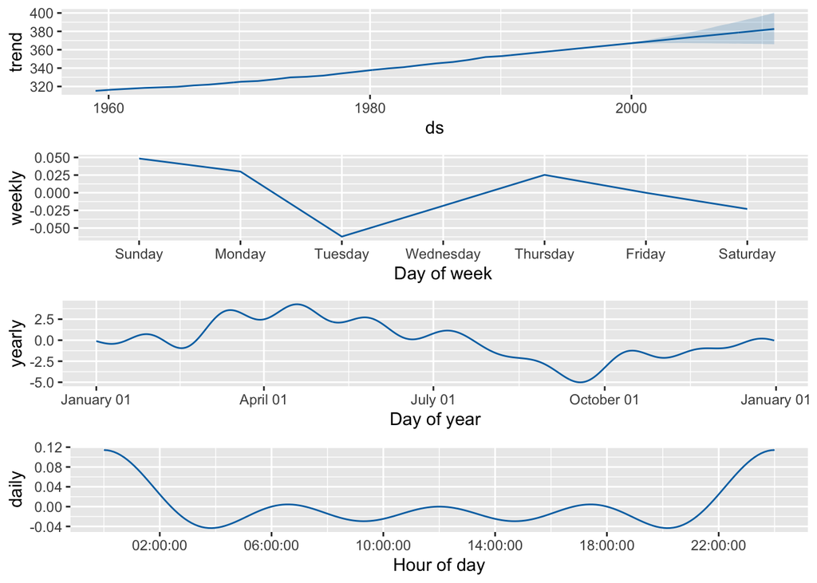

```r
# Now i will generate a code to visualise the individual components of the time series, including trend, yearly, weekly and daily.
prophet::prophet_plot_components(seasonalityfit,prediction)
```

Graph1: According to the data presented in this graph, there is a clear and positive correlation between the years and the concentration of CO2. By observing the slope of the line, we can deduce that the growth between 1960 and 1970 was minimal. However, as the years progressed, the level of CO2 increased significantly, rising from 320 ppm in 1960 to 370 ppm.

In conclusion, the data and graphs produced show a clear correlation between the two variables, and the CO2 rates have been gradually increasing over time at different rates each year.